# Report

### INTRODUCTION

This project is a bare bone exploration of the data mtcars.csv. Make the changes as required.

```r
# Loading the libraries
library(analyzer)
library(dplyr)
library(corrplot)
```

### DATA

First, let’s load the data and take a look at its dimension and first few rows.

```r
tb <- read.csv('~/Documents/mtcars.csv')

# Defining factor variables
factor_vars <- c('cyl', 'vs', 'gear')

# Converting categorical variables into factors
for (i in factor_vars) {
  tb[,i] <- as.factor(tb[,i])
}
```

The dimension of data is

```
Columns: 11
Rows: 32
Unique Rows: 11
```

```r
head(tb)
```

|  | mpg | cyl | disp | hp | drat | wt | qsec | vs | am | gear | carb |
| --- | --- | --- | --- | --- | --- | --- | --- | --- | --- | --- | --- |
| 1 | NA | 6 | 160 | 110 | 3.90 | 2.620 | 16.46 | 0 | 1 | 4 | 4 |
| 2 | 21.0 | 6 | 160 | 110 | 3.90 | 2.875 | 17.02 | 0 | 1 | 4 | 4 |
| 3 | 22.8 | 4 | 108 | 93 | 3.85 | 2.320 | 18.61 | 1 | 1 | 4 | 1 |
| 4 | 21.4 | 6 | 258 | 110 | 3.08 | 3.215 | 19.44 | 1 | 0 | 3 | 1 |
| 5 | 18.7 | 8 | 360 | 175 | 3.15 | 3.440 | 17.02 | 0 | 0 | 3 | 2 |
| 6 | 18.1 | 6 | 225 | 105 | 2.76 | 3.460 | 20.22 | 1 | 0 | 3 | 1 |

#### MISSING VALUES

By plotting the proportion of missing values we can see see which variables has the maximum counts of missing values. From the plot we can see that column ‘mpg’ has the highest number of missing values. Rest columns doesn’t have any missing values.

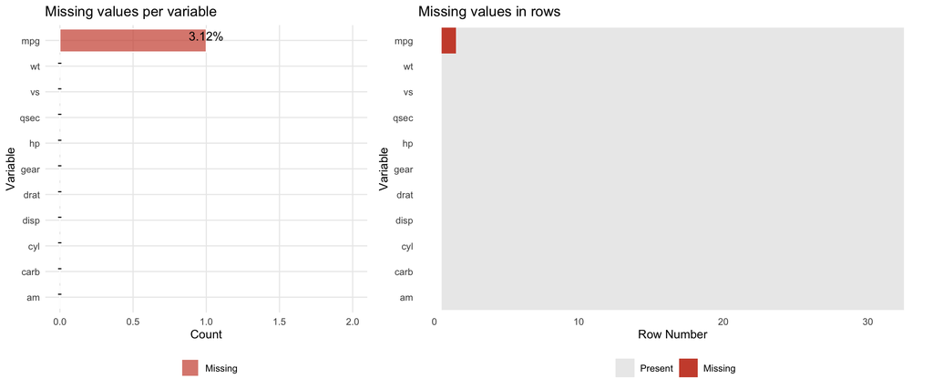

```r
# Plotting the missing values
analyzer::plotNA(tb, row.level = TRUE)
```

#### VARIABLE EXPLORATION

In this section all the individual variables are being explored. Variable **‘cyl’** is selected as the response (or dependent) variable. While, the remaining variables are selected as the explanatory (or independent) variables.

First, let’s create and save all the plots:

```r
variable_plots <- plottrWrapper(tb, yvar = 'cyl',
                                yclass = 'factor', inc.density = T)
```

##### **Variable: mpg**

```r
explainer(tb$mpg)
```

```
tb$mpg (type: numeric)
......................
    distinct    missing    mean    sd    median    0%    20%    40%    60%
          26          1   20.06  6.12      19.2  10.4   15.2   17.8     21
    80%    100%
   24.4    33.9
Box plot:
|.............<===========*==========>.................................|
Legends: | min and max, <==  ==> IQR, * median
```

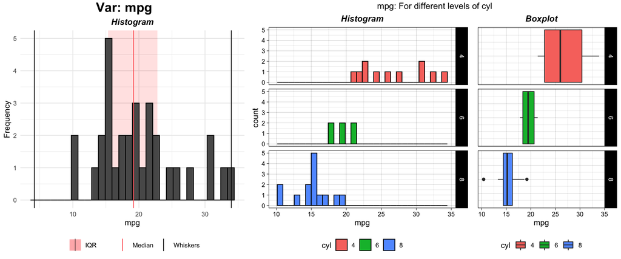

```r
# Plot
plot(variable_plots$mpg)
```

**Normality test**

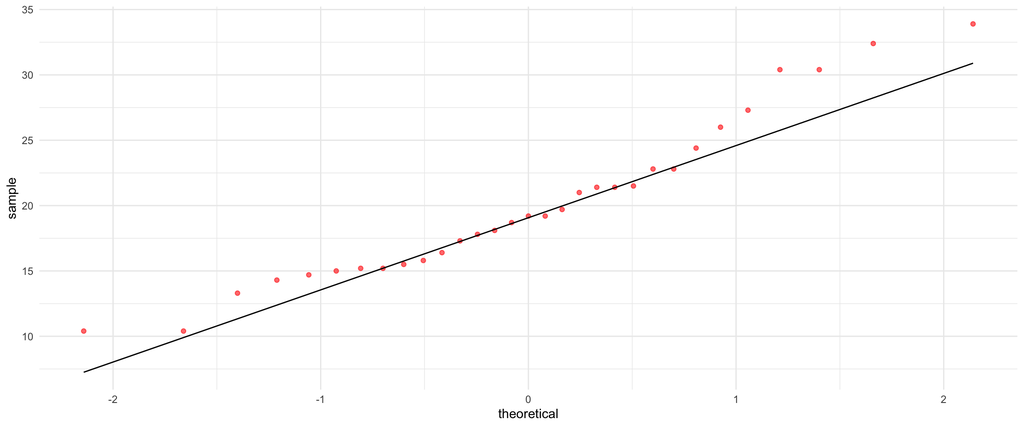

The Anderson-Darling normality test has a p-value of **0.1133233**. Since p-value is not below the significance level (0.05), we do not have sufficient evidence to reject the null hypothesis. Therefore, we can say that this variable **follows the normal distribution**.

##### **Variable: cyl**

```r
explainer(tb$cyl)
```

```
X (type: factor)
................
 distinct missing
        3       0

 Frequency table:
 Value Freq Proportion
     4   11      0.344 |****************************............|(50%)
     6    7      0.219 |******************......................|(50%)
     8   14      0.438 |***********************************.....|(50%)
```

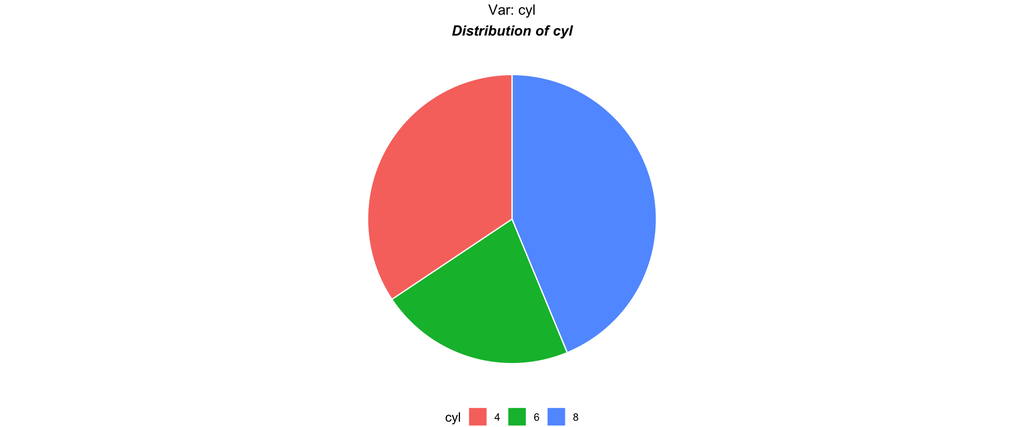

```r
# Plot
plot(variable_plots$cyl)
```

##### **Variable: disp**

```r
explainer(tb$disp)
```

```
tb$disp (type: numeric)
.......................
      distinct      missing      mean      sd      median      0%      20%
            27            0    230.72  123.94       196.3    71.1   120.14
      40%      60%      80%      100%
      160    275.8    350.8       472
Box plot:
|.......<============*=======================>.........................|
Legends: | min and max, <==  ==> IQR, * median
```

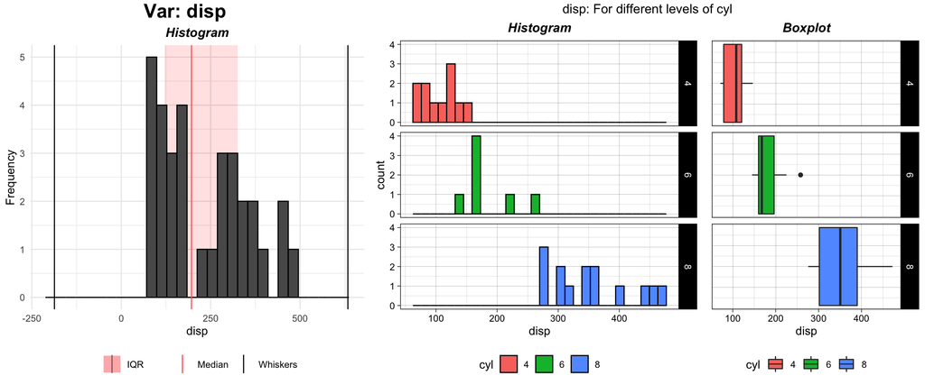

```r
# Plot
plot(variable_plots$disp)
```

**Normality test**

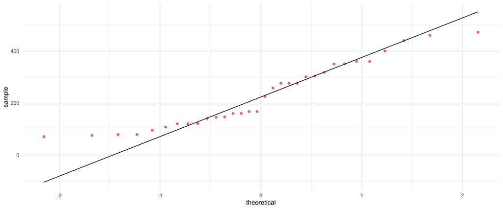

The Anderson-Darling normality test has a p-value of **0.022107**. Since p-value is less than the significance level (0.05), we reject the null hypothesis. Therefore, we can say that this variable **does not follow the normal distribution**.

##### **Variable: hp**

```r
explainer(tb$hp)
```

```
tb$hp (type: integer)
.....................
     distinct     missing     mean     sd     median     0%     20%     40%
           22           0   146.69  68.56        123     52    93.4     110
     60%     80%     100%
     165     200      335
Box plot:
|.........<======*==============>......................................|
Legends: | min and max, <==  ==> IQR, * median

Potential outliers present in this variable
```

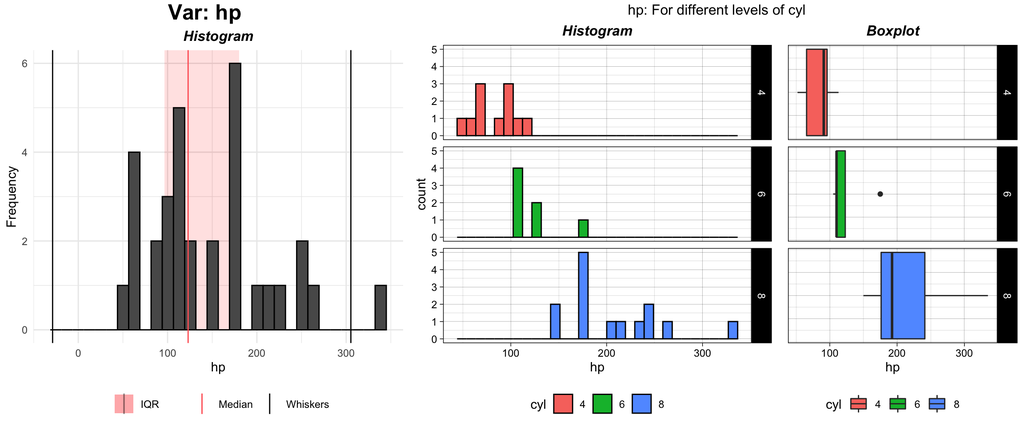

```r
# Plot
plot(variable_plots$hp)
```

**Normality test**

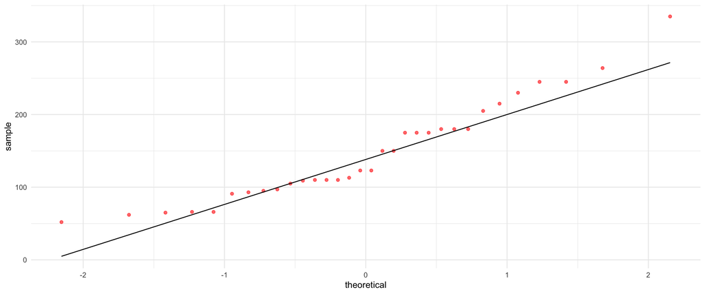

The Anderson-Darling normality test has a p-value of **0.058391**. Since p-value is not below the significance level (0.05), we do not have sufficient evidence to reject the null hypothesis. Therefore, we can say that this variable **follows the normal distribution**.

##### **Variable: drat**

```r
explainer(tb$drat)
```

```
tb$drat (type: numeric)
.......................
    distinct    missing    mean    sd    median    0%    20%    40%    60%
          22          0     3.6  0.53       3.7  2.76   3.07   3.35   3.82
    80%    100%
   4.05    4.93
Box plot:
|.........<===================*======>.................................|
Legends: | min and max, <==  ==> IQR, * median
```

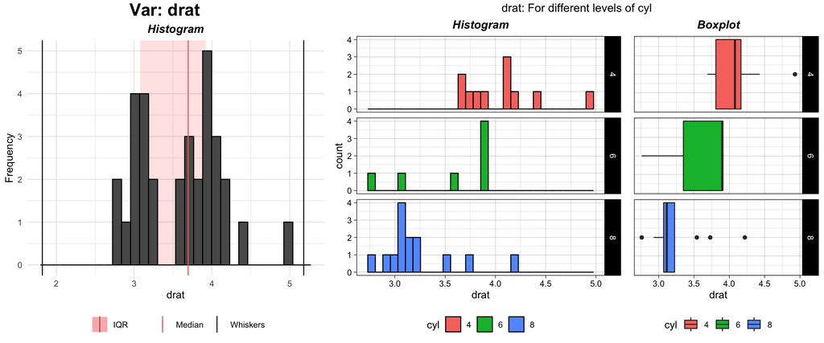

```r
# Plot
plot(variable_plots$drat)
```

**Normality test**

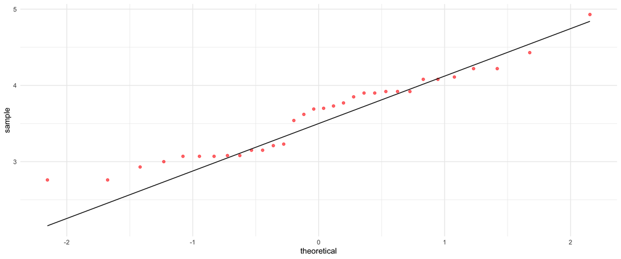

The Anderson-Darling normality test has a p-value of **0.0550071**. Since p-value is not below the significance level (0.05), we do not have sufficient evidence to reject the null hypothesis. Therefore, we can say that this variable **follows the normal distribution**.

##### **Variable: wt**

```r
explainer(tb$wt)
```

```
tb$wt (type: numeric)
.....................
    distinct    missing    mean    sd    median    0%    20%    40%    60%
          29          0    3.22  0.98      3.33  1.51   2.35   3.16   3.44
    80%    100%
   3.77    5.42
Box plot:
|..................<============*=====>................................|
Legends: | min and max, <==  ==> IQR, * median

Potential outliers present in this variable
```

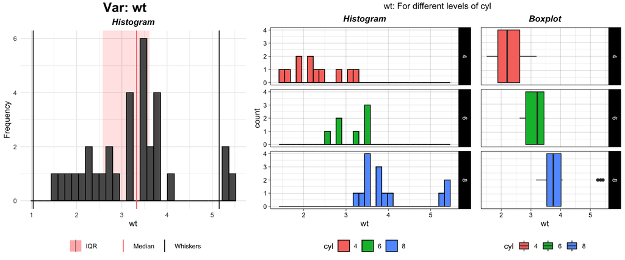

```r
# Plot
plot(variable_plots$wt)
```

**Normality test**

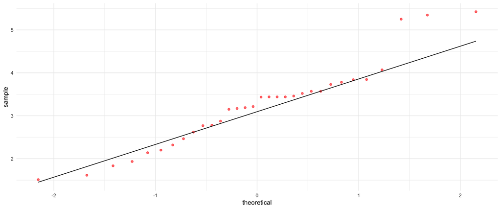

The Anderson-Darling normality test has a p-value of **0.1037719**. Since p-value is not below the significance level (0.05), we do not have sufficient evidence to reject the null hypothesis. Therefore, we can say that this variable **follows the normal distribution**.

##### **Variable: qsec**

```r
explainer(tb$qsec)
```

```
tb$qsec (type: numeric)
.......................
    distinct    missing    mean    sd    median    0%    20%    40%    60%
          30          0   17.85  1.79     17.71  14.5  16.73  17.34  18.18
    80%    100%
  19.33    22.9
Box plot:
|...................<======*=========>.................................|
Legends: | min and max, <==  ==> IQR, * median

Potential outliers present in this variable
```

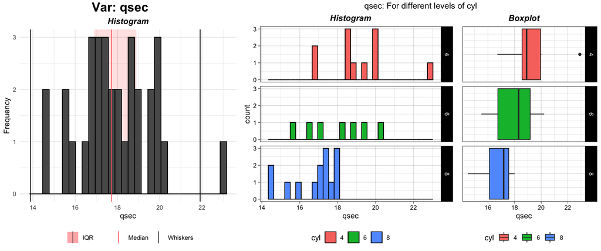

```r
# Plot
plot(variable_plots$qsec)
```

**Normality test**

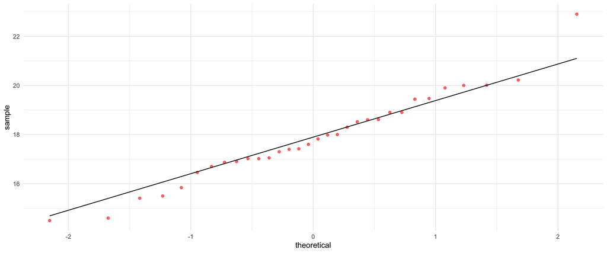

The Anderson-Darling normality test has a p-value of **0.7692999**. Since p-value is not below the significance level (0.05), we do not have sufficient evidence to reject the null hypothesis. Therefore, we can say that this variable **follows the normal distribution**.

##### **Variable: vs**

```r
explainer(tb$vs)
```

```
X (type: factor)
................
 distinct missing
        2       0

 Frequency table:
 Value Freq Proportion
     0   18      0.562 |******************************..........|(75%)
     1   14      0.438 |***********************.................|(75%)
```

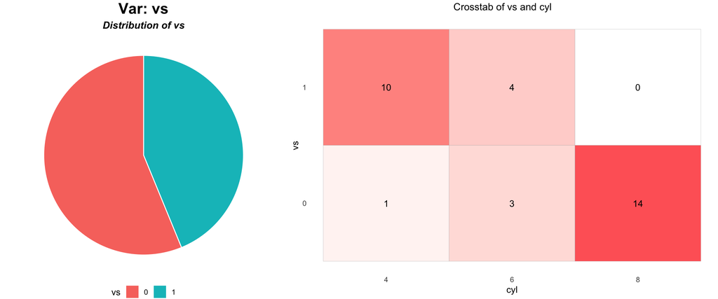

```r
# Plot
plot(variable_plots$vs)
```

##### **Variable: am**

```r
explainer(tb$am)
```

```
tb$am (type: integer)
.....................
   distinct   missing   mean   sd   median   0%   20%   40%   60%   80%   100%
          2         0   0.41  0.5        0    0     0     0   0.6     1      1
Box plot:
No boxplot for this as unique values are < 3.
 Showing frequency table because variable has less distinct values:
 Value Freq Proportion
     0   19      0.594 |********************************........|(75%)
     1   13      0.406 |**********************..................|(75%)
```

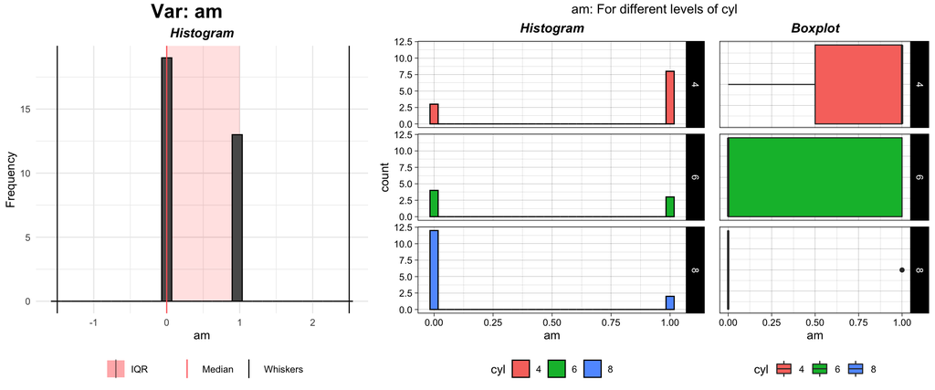

```r
# Plot
plot(variable_plots$am)
```

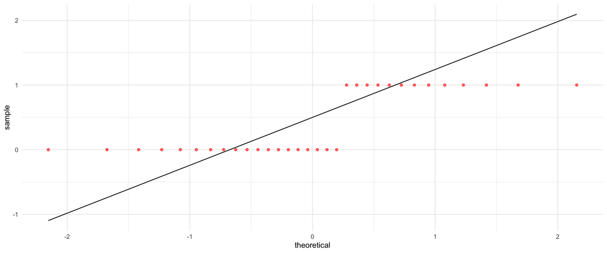

##### **Variable: gear**

```r
explainer(tb$gear)
```

```
X (type: factor)
................
 distinct missing
        3       0

 Frequency table:
 Value Freq Proportion
     3   15      0.469 |**************************************..|(50%)
     4   12      0.375 |******************************..........|(50%)
     5    5      0.156 |************............................|(50%)
```

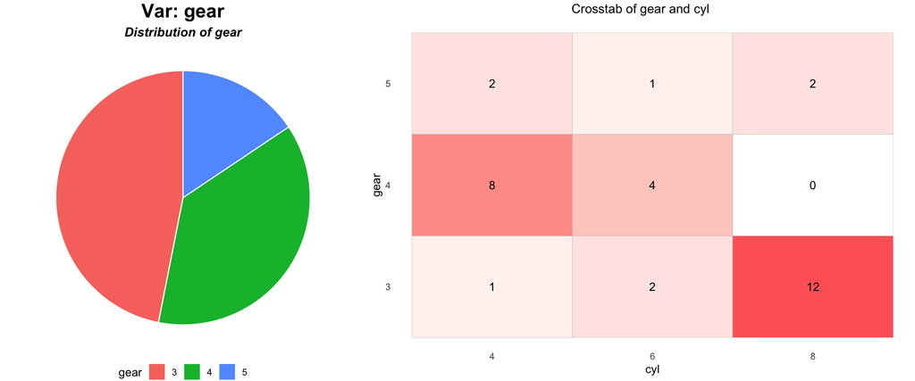

```r
# Plot
plot(variable_plots$gear)
```

##### **Variable: carb**

```r
explainer(tb$carb)
```

```
tb$carb (type: integer)
.......................
    distinct    missing    mean    sd    median    0%    20%    40%    60%
           6          0    2.81  1.62         2     1    1.2      2      3
    80%    100%
      4       8
Box plot:
|........<*====================>........................................|
Legends: | min and max, <==  ==> IQR, * median

Potential outliers present in this variable

 Showing frequency table because variable has less distinct values:
 Value Freq Proportion
     1    7      0.219 |******************......................|(50%)
     2   10      0.312 |*************************...............|(50%)
     3    3      0.094 |********................................|(50%)
     4   10      0.312 |*************************...............|(50%)
     6    1      0.031 |**......................................|(50%)
     8    1      0.031 |**......................................|(50%)
```

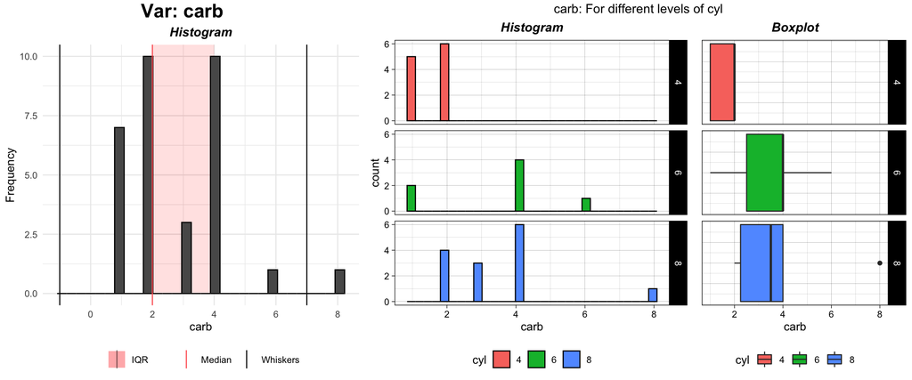

```r
# Plot
plot(variable_plots$carb)
```

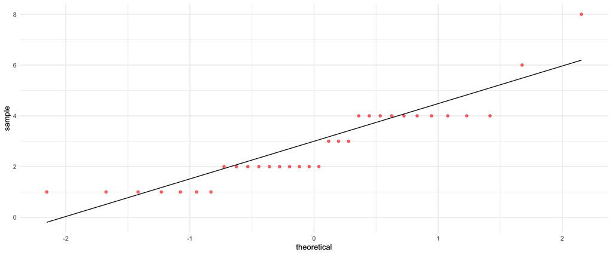

#### CORRELATION & ASSOCIATION

In general there can be three types of association based on the data type of variables - 1. Between 2 continuous (numeric) variables 2. Between 2 categorical variables 3. Between 1 continuous and 1 categorical variables

In this section, each type will be analyzed separately. **association** function can be used to calculate these automatically.

```r
corr_all <- association(tb, categorical = c('cyl', 'vs', 'gear'))
```

##### Between 2 continuous (numeric) variables

For this case, the **association** function internally utilizes the **cor** function. Since there are some variables which may not follow the normality assumption, we will keep the method as ‘auto’. This will assign the method automatically to all the variables pair based on normality tests.

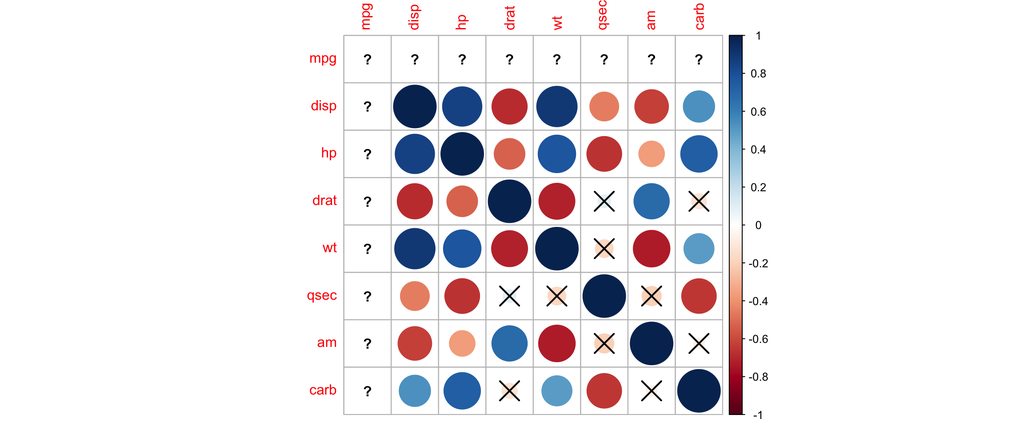

```r
corrplot(corr_all$continuous_corr, p.mat = corr_all$continuous_pvalue, sig.level = .2)
```

The above correlations are either Pearson or Spearman, decided by the function based on the normality tests. A value close to 0 means no linear correlation between the variables. As values increases towards +1, the linear positive correlation increases (one variable increases as other increases). Similarly, as value decreases towards -1, the linear negative correlation increases (as one variable increases, other decreases). The insignificant correlation (based on p-value) are crossed.

##### Between 2 categorical variables

Association can be measured between categorical variables using the chi-square test of independence on two-way contingency tables. A small p-value indicates that some association between the variables is present. Using the Chi-Square test statistic a measure of association can be calculated which is known as Cramer’s V. This gives a value between 0 to 1. Like correlation we can measure the magnitude of association using Cramer’s V.

The Cramer’s V can be calculated using the Chi-Square test statistic using:

$$V = \sqrt{\frac{\chi ^2}{n*min(k-1,r-1))}}$$

Where: **$\chi ^{2}$** is derived from Pearson’s chi-squared test **$n$** is the grand total of observations **$k$** is the number of columns **$r$** is the number of rows.

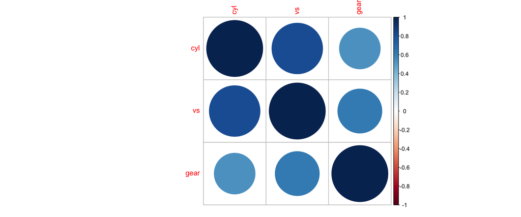

```r
corrplot(corr_all$categorical_cramers, p.mat = corr_all$categorical_pvalue, sig.level = .2)
```

One thing to note is that Cramer’s V doesn’t give direction of association using negative and positive values like Pearson / Spearman correlation. But this only give magnitude of association.